# US Core Inflation Forecast

## Data Sources

ISM PMI Manufacturing

- https://www.ismworld.org/supply-management-news-and-reports/reports/ism-report-on-business/ ISM PMI Services
- https://www.ismworld.org/supply-management-news-and-reports/reports/ism-report-on-business/ ISM PMI Manufacturing Prices
- https://www.ismworld.org/supply-management-news-and-reports/reports/ism-report-on-business/ ISM PMI Services Prices
- https://www.ismworld.org/supply-management-news-and-reports/reports/ism-report-on-business/ UMC Consumer Sentiment
- https://fred.stlouisfed.org/series/UMCSENT FED Funds
- https://fred.stlouisfed.org/series/FEDFUNDS 10 Year Tresury
- https://fred.stlouisfed.org/series/GS10 M2
- https://fred.stlouisfed.org/series/M2NS Capacity Utilization
- https://fred.stlouisfed.org/series/TCU Manufacturing New Orders
- https://fred.stlouisfed.org/series/UMTMNO Nonfarm Employment
- https://fred.stlouisfed.org/series/PAYNSA Unemployment Rate
- https://fred.stlouisfed.org/series/UNRATE Retail Trade
- https://fred.stlouisfed.org/series/RSXFSN CPI Core
- https://fred.stlouisfed.org/series/CPILFENS

## Obtaining, cleaning and preparing data

```python
import pandas as pd
import pandas_datareader.data as web
import numpy as np
import datetime
```

```python
#datetime data range

from_date = datetime.date(1900,1,1)
to_date = datetime.date(2021,11,1)
```

```python
#obtaining data from Federal Reserve Economic Data | FRED | St. Louis Fed

fred_data = web.DataReader(['FEDFUNDS','GS10','M2NS','PERMIT','UMCSENT','TCU','UMTMNO',
                            'PAYNSA','UNRATE','RSXFSN','CPILFENS'],
                               data_source='fred',start=from_date, end=to_date)
fred_data.dropna(inplace=True)
```

```python
fred_data.head()
```

| DATE | FEDFUNDS | GS10 | M2NS | PERMIT | UMCSENT | TCU | UMTMNO | PAYNSA | UNRATE | RSXFSN | CPILFENS |
| --- | --- | --- | --- | --- | --- | --- | --- | --- | --- | --- | --- |
| 1992-02-01 | 4.06 | 7.34 | 3390.1 | 1146.0 | 68.8 | 79.8145 | 228230.0 | 106977 | 7.4 | 131244.0 | 145.6 |
| 1992-03-01 | 3.98 | 7.54 | 3404.8 | 1082.0 | 76.0 | 80.3033 | 245052.0 | 107495 | 7.4 | 142488.0 | 146.4 |
| 1992-04-01 | 3.73 | 7.48 | 3418.9 | 1054.0 | 77.2 | 80.7450 | 236726.0 | 108330 | 7.4 | 147175.0 | 146.6 |
| 1992-05-01 | 3.82 | 7.39 | 3388.0 | 1056.0 | 79.2 | 80.8311 | 238178.0 | 109137 | 7.6 | 152420.0 | 146.7 |
| 1992-06-01 | 3.76 | 7.26 | 3388.7 | 1057.0 | 80.4 | 80.6997 | 254919.0 | 109626 | 7.8 | 151849.0 | 146.9 |

```python
# changing working directory

import os

cwd = os.getcwd()
os.chdir('D:/Data Science Projects/US_Core_Inflation_Forecast')
print("Current working directory: {0}".format(cwd))

# obtaining data from csv file (Institute for Supply and Management PMI)

ism_man_data = pd.read_csv('ISM Manufacturing.csv')
ism_serv_data = pd.read_csv('ISM Services.csv')
```

```
Current working directory: D:\Data Science Projects\US_Core_Inflation_Forecast\IPYNB Files
```

```python
print(ism_man_data.head())
print(ism_serv_data.head())
```

```
         Release Date Observation Date  PMI M Composite  PMI M Prices
0  Jan 01, 1970 (Dec)           Dec-69             52.0          82.2
1  Feb 01, 1970 (Jan)           Jan-70             48.7          80.6
2  Mar 01, 1970 (Feb)           Feb-70             47.4          74.5
3  Apr 01, 1970 (Mar)           Mar-70             46.9          67.8
4  May 01, 1970 (Apr)           Apr-70             45.0          75.1
         Release Date Observation Date  PMI S Composite  PMI S Prices
0  Aug 01, 1997 (Jul)           Jul-97             56.7          50.9
1  Sep 01, 1997 (Aug)           Aug-97             62.0          53.3
2  Oct 01, 1997 (Sep)           Sep-97             56.2          53.1
3  Nov 01, 1997 (Oct)           Oct-97             56.6          53.1
4  Dec 01, 1997 (Nov)           Nov-97             58.5          54.3
```

```python
# cleaning, sorting and merging databases

    #ISM databases
ism_data = pd.merge(left=ism_serv_data, right=ism_man_data, how='inner', on='Observation Date')
ism_data.drop(columns=['Release Date_x','Release Date_y'],inplace=True)
ism_data['Observation Date'] = pd.to_datetime(arg=ism_data['Observation Date'], format='%b-%y', infer_datetime_format=True)
ism_data.set_index('Observation Date', inplace=True)

    #FRED databases
fred_data.columns = ['FED Funds Rate','10 Year Treasury Rate','M2','Building Permits',
                    'Consumer Sentiment','Capacity Utilization','Manufacturing New Orders',
                     'Nonfarm Employment','Unemployment Rate SA','Retail Trade','CPI Core NSA']
```

```python
# checking data types

print(fred_data.dtypes)
print(ism_data.dtypes)
```

```
FED Funds Rate              float64
10 Year Treasury Rate       float64
M2                          float64
Building Permits            float64
Consumer Sentiment          float64
Capacity Utilization        float64
Manufacturing New Orders    float64
Nonfarm Employment            int64
Unemployment Rate SA        float64
Retail Trade                float64
CPI Core NSA                float64
dtype: object
PMI S Composite    float64
PMI S Prices       float64
PMI M Composite    float64
PMI M Prices       float64
dtype: object
```

```python
# merging ism and fred data

data_all = pd.merge(ism_data,fred_data,how='inner',left_index=True, right_index=True)
data_all.tail()
```

|  | PMI S Composite | PMI S Prices | PMI M Composite | PMI M Prices | FED Funds Rate | 10 Year Treasury Rate | M2 | Building Permits | Consumer Sentiment | Capacity Utilization | Manufacturing New Orders | Nonfarm Employment | Unemployment Rate SA | Retail Trade | CPI Core NSA |
| --- | --- | --- | --- | --- | --- | --- | --- | --- | --- | --- | --- | --- | --- | --- | --- |
| 2021-07-01 | 64.1 | 82.3 | 59.5 | 85.7 | 0.10 | 1.32 | 20609.1 | 1630.0 | 81.2 | 76.1550 | 492093.0 | 146536 | 5.4 | 558031.0 | 279.146 |
| 2021-08-01 | 61.7 | 75.4 | 59.9 | 79.4 | 0.09 | 1.28 | 20810.7 | 1721.0 | 70.3 | 75.9923 | 525042.0 | 147012 | 5.2 | 557018.0 | 279.507 |
| 2021-09-01 | 61.9 | 77.5 | 61.1 | 81.2 | 0.08 | 1.37 | 20995.6 | 1586.0 | 72.8 | 75.2106 | 529459.0 | 147650 | 4.7 | 536229.0 | 279.884 |
| 2021-10-01 | 66.7 | 82.9 | 60.8 | 85.7 | 0.08 | 1.58 | 21178.6 | 1653.0 | 71.7 | 76.0962 | 524174.0 | 149245 | 4.6 | 559399.0 | 281.617 |
| 2021-11-01 | 69.1 | 82.3 | 61.1 | 82.4 | 0.08 | 1.56 | 21425.9 | 1717.0 | 67.4 | 76.6150 | 517146.0 | 150098 | 4.2 | 580162.0 | 282.754 |

```python
# data manipulation

data_all['Released Date'] = data_all.index + pd.DateOffset(months=1) # release date for economic indicators (1 month lag)
data_all['PMI Composite Avg'] = np.average(data_all[['PMI S Composite','PMI M Composite']],axis=1) # PMI Composite Average
data_all['PMI Prices Avg'] = np.average(data_all[['PMI S Prices','PMI M Prices']],axis=1) # PMI Prices Average

data_all = data_all[['Released Date',
                     'PMI M Composite','PMI S Composite','PMI Composite Avg',
                     'PMI M Prices','PMI S Prices','PMI Prices Avg',
                     'Building Permits','Consumer Sentiment',
                     'FED Funds Rate','10 Year Treasury Rate','M2',
                     'Capacity Utilization','Manufacturing New Orders',
                     'Nonfarm Employment','Unemployment Rate SA',
                     'Retail Trade',
                     'CPI Core NSA']]

# percentage change calculation

data_calc = data_all.copy(deep=True)
data_calc['Building Permits YoY'] = data_calc['Building Permits'].pct_change(periods=12) * 100
data_calc['Consumer Sentiment YoY'] = data_calc['Consumer Sentiment'].pct_change(periods=12) * 100
data_calc['M2 YoY'] = data_calc['M2'].pct_change(periods=12) * 100
data_calc['Capacity Utilization YoY'] = data_calc['Capacity Utilization'].pct_change(periods=12)
data_calc['Manufacturing New Orders YoY'] = data_calc['Manufacturing New Orders'].pct_change(periods=12) * 100
data_calc['Nonfarm Employment YoY'] = data_calc['Nonfarm Employment'].pct_change(periods=12) * 100
data_calc['Unemployment Rate SA Adj'] = data_calc['Unemployment Rate SA'] * (-1)
data_calc['Retail Trade YoY'] = data_calc['Retail Trade'].pct_change(periods=12) * 100
data_calc['CPI Core NSA YoY'] = data_calc['CPI Core NSA'].pct_change(periods=12) * 100
```

```python
data_calc.head(15)
```

|  | Released Date | PMI M Composite | PMI S Composite | PMI Composite Avg | PMI M Prices | PMI S Prices | PMI Prices Avg | Building Permits | Consumer Sentiment | FED Funds Rate | ... | CPI Core NSA | Building Permits YoY | Consumer Sentiment YoY | M2 YoY | Capacity Utilization YoY | Manufacturing New Orders YoY | Nonfarm Employment YoY | Unemployment Rate SA Adj | Retail Trade YoY | CPI Core NSA YoY |
| --- | --- | --- | --- | --- | --- | --- | --- | --- | --- | --- | --- | --- | --- | --- | --- | --- | --- | --- | --- | --- | --- |
| 1997-07-01 | 1997-08-01 | 57.7 | 56.7 | 57.20 | 52.0 | 50.9 | 51.45 | 1440.0 | 107.1 | 5.52 | ... | 169.5 | NaN | NaN | NaN | NaN | NaN | NaN | -4.9 | NaN | NaN |
| 1997-08-01 | 1997-09-01 | 56.3 | 62.0 | 59.15 | 52.1 | 53.3 | 52.70 | 1449.0 | 104.4 | 5.54 | ... | 169.6 | NaN | NaN | NaN | NaN | NaN | NaN | -4.8 | NaN | NaN |
| 1997-09-01 | 1997-10-01 | 53.9 | 56.2 | 55.05 | 53.0 | 53.1 | 53.05 | 1494.0 | 106.0 | 5.54 | ... | 170.0 | NaN | NaN | NaN | NaN | NaN | NaN | -4.9 | NaN | NaN |
| 1997-10-01 | 1997-11-01 | 56.4 | 56.6 | 56.50 | 53.6 | 53.1 | 53.35 | 1499.0 | 105.6 | 5.50 | ... | 170.8 | NaN | NaN | NaN | NaN | NaN | NaN | -4.7 | NaN | NaN |
| 1997-11-01 | 1997-12-01 | 55.7 | 58.5 | 57.10 | 52.1 | 54.3 | 53.20 | 1469.0 | 107.2 | 5.52 | ... | 170.8 | NaN | NaN | NaN | NaN | NaN | NaN | -4.6 | NaN | NaN |
| 1997-12-01 | 1998-01-01 | 54.5 | 55.5 | 55.00 | 52.2 | 54.9 | 53.55 | 1456.0 | 102.1 | 5.50 | ... | 170.7 | NaN | NaN | NaN | NaN | NaN | NaN | -4.7 | NaN | NaN |
| 1998-01-01 | 1998-02-01 | 53.8 | 57.0 | 55.40 | 47.0 | 52.7 | 49.85 | 1555.0 | 106.6 | 5.56 | ... | 171.2 | NaN | NaN | NaN | NaN | NaN | NaN | -4.6 | NaN | NaN |
| 1998-02-01 | 1998-03-01 | 52.9 | 56.2 | 54.55 | 45.5 | 51.6 | 48.55 | 1647.0 | 110.4 | 5.51 | ... | 172.1 | NaN | NaN | NaN | NaN | NaN | NaN | -4.6 | NaN | NaN |
| 1998-03-01 | 1998-04-01 | 52.9 | 54.7 | 53.80 | 44.2 | 47.9 | 46.05 | 1605.0 | 106.5 | 5.49 | ... | 172.6 | NaN | NaN | NaN | NaN | NaN | NaN | -4.7 | NaN | NaN |
| 1998-04-01 | 1998-05-01 | 52.2 | 54.9 | 53.55 | 40.5 | 46.8 | 43.65 | 1547.0 | 108.7 | 5.45 | ... | 173.0 | NaN | NaN | NaN | NaN | NaN | NaN | -4.3 | NaN | NaN |
| 1998-05-01 | 1998-06-01 | 50.9 | 56.2 | 53.55 | 41.1 | 47.2 | 44.15 | 1554.0 | 106.5 | 5.49 | ... | 173.1 | NaN | NaN | NaN | NaN | NaN | NaN | -4.4 | NaN | NaN |
| 1998-06-01 | 1998-07-01 | 48.9 | 55.1 | 52.00 | 39.3 | 45.5 | 42.40 | 1551.0 | 105.6 | 5.56 | ... | 173.0 | NaN | NaN | NaN | NaN | NaN | NaN | -4.5 | NaN | NaN |
| 1998-07-01 | 1998-08-01 | 49.2 | 55.8 | 52.50 | 38.4 | 47.0 | 42.70 | 1610.0 | 105.2 | 5.54 | ... | 173.3 | 11.805556 | -1.774043 | 7.010336 | -0.027328 | -2.324947 | 2.579002 | -4.5 | 4.228272 | 2.241888 |
| 1998-08-01 | 1998-09-01 | 49.3 | 53.5 | 51.40 | 37.8 | 47.9 | 42.85 | 1654.0 | 104.4 | 5.55 | ... | 173.8 | 14.147688 | 0.000000 | 6.756552 | -0.016870 | 0.173852 | 2.719938 | -4.5 | 2.195308 | 2.476415 |
| 1998-09-01 | 1998-10-01 | 48.7 | 55.0 | 51.85 | 34.0 | 46.2 | 40.10 | 1577.0 | 100.9 | 5.51 | ... | 174.2 | 5.555556 | -4.811321 | 7.393664 | -0.026444 | -0.035356 | 2.540561 | -4.6 | 3.723655 | 2.470588 |

15 rows × 27 columns

```python
# time shifting and correlation sweet spot

data_shift_pc = data_calc[12:270] # selecting pre Covid-19 crisis data only
data_shift_ci = data_calc[12:] # selecting all available data (Covid-19 crisis included)

def data_corr_test(data_shift):

    data_shift = data_shift[['PMI M Composite','PMI S Composite','PMI Composite Avg',
                             'PMI M Prices','PMI S Prices','PMI Prices Avg',
                             'Building Permits','Consumer Sentiment',
                             'FED Funds Rate','10 Year Treasury Rate',
                             'Capacity Utilization','Unemployment Rate SA Adj',
                             'Building Permits YoY','Consumer Sentiment YoY','M2 YoY',
                             'Capacity Utilization YoY','Manufacturing New Orders YoY',
                             'Nonfarm Employment YoY','Retail Trade YoY',
                            'CPI Core NSA YoY']]

    time_shift = list(range(0,37))
    columns_x = data_shift.columns[0:19]
    column_y = data_shift.columns[19]
    corr_results = {} # key:columns, values:corr

    #shifting
    for x in columns_x:
        d = data_shift[[x,column_y]]
        corr_results.setdefault(x,[])
        for t in time_shift:
            pearson = d[x].shift(t).corr(d[column_y],method='pearson')
            corr_results[x].append(pearson)

    #summarizing results
    time_shift = {}
    max_corr = {}
    for c in columns_x:
        time_shift[c] = corr_results[c].index(max(corr_results[c]))
        max_corr[c] = max(corr_results[c])

    results = [time_shift, max_corr]
    return results
```

```python
# comparing correlation intensity prior to crisis and after the crisis

data_comparison1 = pd.DataFrame(data=data_corr_test(data_shift_pc)[1],index=[0])
data_comparison1 = data_comparison1.transpose()
data_comparison1.columns = ['Pre Crisis Correlation']

data_comparison2 = pd.DataFrame(data=data_corr_test(data_shift_ci)[1],index=[0])
data_comparison2 = data_comparison2.transpose()
data_comparison2.columns = ['With Crisis Correlation']

data_comparison = pd.concat([data_comparison1,data_comparison2],axis=1)
data_comparison['Correlation Difference'] = data_comparison['Pre Crisis Correlation']-data_comparison['With Crisis Correlation']
data_comparison = data_comparison.round(2)
data_comparison.sort_values(by='Correlation Difference')
```

|  | Pre Crisis Correlation | With Crisis Correlation | Correlation Difference |
| --- | --- | --- | --- |
| M2 YoY | 0.34 | 0.47 | -0.13 |
| PMI S Prices | 0.33 | 0.31 | 0.02 |
| Building Permits YoY | 0.38 | 0.33 | 0.05 |
| PMI Prices Avg | 0.31 | 0.25 | 0.06 |
| PMI M Prices | 0.30 | 0.20 | 0.10 |
| Building Permits | 0.52 | 0.42 | 0.10 |
| Consumer Sentiment YoY | 0.41 | 0.28 | 0.13 |
| Consumer Sentiment | 0.65 | 0.52 | 0.14 |
| Unemployment Rate SA Adj | 0.65 | 0.51 | 0.15 |
| Retail Trade YoY | 0.68 | 0.49 | 0.19 |
| PMI S Composite | 0.70 | 0.46 | 0.24 |
| Manufacturing New Orders YoY | 0.53 | 0.29 | 0.24 |
| 10 Year Treasury Rate | 0.40 | 0.15 | 0.25 |
| FED Funds Rate | 0.64 | 0.38 | 0.26 |
| Capacity Utilization YoY | 0.57 | 0.30 | 0.26 |
| Nonfarm Employment YoY | 0.74 | 0.47 | 0.27 |
| PMI Composite Avg | 0.65 | 0.38 | 0.27 |
| PMI M Composite | 0.59 | 0.33 | 0.27 |
| Capacity Utilization | 0.76 | 0.40 | 0.35 |

```python
#selection of variables for further evaluation

_ = pd.DataFrame(data_corr_test(data_shift_pc)).transpose().round(2).sort_values(by=1,ascending=False)
_.columns = ['Time shift (Months)','Correlation']
_.drop(index=['PMI Composite Avg','Unemployment Rate SA Adj','PMI M Composite','Capacity Utilization YoY',
             'Consumer Sentiment YoY','10 Year Treasury Rate','Building Permits YoY','M2 YoY',
             'PMI Prices Avg','PMI M Prices'])
```

|  | Time shift (Months) | Correlation |
| --- | --- | --- |
| Capacity Utilization | 15.0 | 0.76 |
| Nonfarm Employment YoY | 15.0 | 0.74 |
| PMI S Composite | 18.0 | 0.70 |
| Retail Trade YoY | 18.0 | 0.68 |
| Consumer Sentiment | 21.0 | 0.65 |
| FED Funds Rate | 8.0 | 0.64 |
| Manufacturing New Orders YoY | 17.0 | 0.53 |
| Building Permits | 18.0 | 0.52 |
| PMI S Prices | 17.0 | 0.33 |

#### Short Summary of the results above

Money Supply (M2) is the only indicator that shows better correlation with data including Covid reccession than data until Covid pandemic (end of 2019.). Huge injections by the FED during the lockdown could explain this phenomenon, meaning that big increase in money supply could be one of the main reasons for the jump in core inflation (excluding food and energy) during the last few months.

Purchasing Managers Index Prices component shows negligible difference in two observed data, including Building Permits.

All other indicators show small to medium difference in two observed data, some of the most notable being manufacturing and interest rate indicators, where difference ranges from 0.25 to 0.35.

Economic slowdown caused by the coronavirus pandemic was very volatile. Due to this event, majority of economic indicators show drop in performance for predicting core inflation. To avoid this volatile effect, next observations and modelling will be performed on the data NOT containing period of coronavirus pandemic (2020. and onwards).

```python
# data adjusting

time_shift = data_corr_test(data_shift_pc)[0]
col_adj = {'PMI S Composite':time_shift['PMI S Composite'],'PMI S Prices':time_shift['PMI S Prices'],
           'Building Permits':time_shift['Building Permits'],'Consumer Sentiment':time_shift['Consumer Sentiment'],
           'FED Funds Rate':time_shift['FED Funds Rate'],'Capacity Utilization':time_shift['Capacity Utilization'],
           'Manufacturing New Orders YoY':time_shift['Manufacturing New Orders YoY'],
           'Nonfarm Employment YoY':time_shift['Nonfarm Employment YoY'],
           'Retail Trade YoY':time_shift['Retail Trade YoY'],'CPI Core NSA YoY':0}
data_adj = data_shift_pc.copy(deep=True)
data_adj = data_adj[col_adj.keys()]

#reseting index for concat
data_adj['Covering Date'] = data_adj.index
data_adj.reset_index(drop=True, inplace=True)

#creating new table for 2 year forward empty datetime space
new_rows = {'Covering Date':pd.date_range(start='2020-01-01',end='2022-01-01',freq='MS'),
            'PMI S Composite':np.nan,'PMI S Prices':np.nan,
            'Building Permits':np.nan,'Consumer Sentiment':np.nan,
           'FED Funds Rate':np.nan,'Capacity Utilization':np.nan,
           'Manufacturing New Orders YoY':np.nan,'Nonfarm Employment YoY':np.nan,'Retail Trade YoY':np.nan,
           'CPI Core NSA YoY':np.nan}
new_df = pd.DataFrame(new_rows)

#concating tables together
data_final = pd.concat([data_adj,new_df],ignore_index=True)
data_final['Covering Date'] = data_final['Covering Date'].dt.strftime('%m-%Y')

#shifting values
data_final['PMI S Composite'] = data_final['PMI S Composite'].shift(col_adj['PMI S Composite'])
data_final['PMI S Prices'] = data_final['PMI S Prices'].shift(col_adj['PMI S Prices'])
data_final['Building Permits'] = data_final['Building Permits'].shift(col_adj['Building Permits'])
data_final['Consumer Sentiment'] = data_final['Consumer Sentiment'].shift(col_adj['Consumer Sentiment'])
data_final['FED Funds Rate'] = data_final['FED Funds Rate'].shift(col_adj['FED Funds Rate'])
data_final['Capacity Utilization'] = data_final['Capacity Utilization'].shift(col_adj['Capacity Utilization'])
data_final['Manufacturing New Orders YoY'] = data_final['Manufacturing New Orders YoY'].shift(col_adj['Manufacturing New Orders YoY'])
data_final['Nonfarm Employment YoY'] = data_final['Nonfarm Employment YoY'].shift(col_adj['Nonfarm Employment YoY'])
data_final['Retail Trade YoY'] = data_final['Retail Trade YoY'].shift(col_adj['Retail Trade YoY'])

#round on 2 decimal places and change columns order
data_final[['Capacity Utilization','Manufacturing New Orders YoY','Nonfarm Employment YoY',
            'Retail Trade YoY','CPI Core NSA YoY']] = data_final[['Capacity Utilization','Manufacturing New Orders YoY',
                                                    'Nonfarm Employment YoY','Retail Trade YoY','CPI Core NSA YoY']].round(2)
data_final = data_final[['Covering Date','PMI S Composite','PMI S Prices',
                         'Building Permits','Consumer Sentiment','FED Funds Rate','Manufacturing New Orders YoY',
                         'Capacity Utilization','Nonfarm Employment YoY','Retail Trade YoY',
                         'CPI Core NSA YoY']]

data_final.tail(26)
```

|  | Covering Date | PMI S Composite | PMI S Prices | Building Permits | Consumer Sentiment | FED Funds Rate | Manufacturing New Orders YoY | Capacity Utilization | Nonfarm Employment YoY | Retail Trade YoY | CPI Core NSA YoY |
| --- | --- | --- | --- | --- | --- | --- | --- | --- | --- | --- | --- |
| 257 | 12-2019 | 59.1 | 63.4 | 1320.0 | 101.4 | 2.42 | 9.57 | 79.76 | 1.62 | 4.86 | 2.26 |
| 258 | 01-2020 | 55.7 | 62.8 | 1328.0 | 98.8 | 2.39 | 9.47 | 79.54 | 1.60 | 5.96 | NaN |
| 259 | 02-2020 | 58.5 | 64.2 | 1264.0 | 98.0 | 2.38 | 4.20 | 79.37 | 1.53 | 5.61 | NaN |
| 260 | 03-2020 | 61.6 | 61.7 | 1289.0 | 98.2 | 2.40 | 6.20 | 79.21 | 1.56 | 1.11 | NaN |
| 261 | 04-2020 | 60.3 | 64.3 | 1275.0 | 97.9 | 2.13 | 0.49 | 78.66 | 1.70 | 5.76 | NaN |
| 262 | 05-2020 | 60.7 | 57.6 | 1318.0 | 96.2 | 2.04 | -0.53 | 78.11 | 1.39 | 3.90 | NaN |
| 263 | 06-2020 | 57.6 | 59.4 | 1338.0 | 100.1 | 1.83 | 6.01 | 78.09 | 1.36 | -0.70 | NaN |
| 264 | 07-2020 | 56.7 | 54.4 | 1295.0 | 98.6 | 1.55 | 1.74 | 77.52 | 1.41 | 2.48 | NaN |
| 265 | 08-2020 | 59.7 | 58.7 | 1304.0 | 97.5 | 1.55 | 1.08 | 77.57 | 1.23 | 1.13 | NaN |
| 266 | 09-2020 | 56.1 | 55.7 | 1316.0 | 98.3 | NaN | 2.16 | 77.42 | 1.19 | 0.49 | NaN |
| 267 | 10-2020 | 55.5 | 55.4 | 1337.0 | 91.2 | NaN | -1.84 | 77.09 | 1.27 | 5.40 | NaN |
| 268 | 11-2020 | 56.9 | 58.9 | 1337.0 | 93.8 | NaN | -4.25 | 77.50 | 1.25 | 2.55 | NaN |
| 269 | 12-2020 | 55.1 | 56.5 | 1276.0 | 98.4 | NaN | 1.32 | 77.16 | 1.31 | 1.13 | NaN |
| 270 | 01-2021 | 53.7 | 58.2 | 1369.0 | 97.2 | NaN | -3.12 | 76.47 | 1.29 | 4.60 | NaN |
| 271 | 02-2021 | 56.4 | 60.0 | 1479.0 | 100.0 | NaN | -2.56 | 76.83 | 1.37 | 3.83 | NaN |
| 272 | 03-2021 | 52.6 | 56.6 | 1439.0 | 98.2 | NaN | -1.19 | 76.53 | 1.34 | 2.97 | NaN |
| 273 | 04-2021 | 54.7 | 58.5 | 1509.0 | 98.4 | NaN | -2.19 | NaN | NaN | 3.29 | NaN |
| 274 | 05-2021 | 53.9 | 58.5 | 1509.0 | 89.8 | NaN | 1.18 | NaN | NaN | 2.11 | NaN |
| 275 | 06-2021 | 55.0 | NaN | 1453.0 | 93.2 | NaN | NaN | NaN | NaN | 5.66 | NaN |
| 276 | 07-2021 | NaN | NaN | NaN | 95.5 | NaN | NaN | NaN | NaN | NaN | NaN |
| 277 | 08-2021 | NaN | NaN | NaN | 96.8 | NaN | NaN | NaN | NaN | NaN | NaN |
| 278 | 09-2021 | NaN | NaN | NaN | 99.3 | NaN | NaN | NaN | NaN | NaN | NaN |
| 279 | 10-2021 | NaN | NaN | NaN | NaN | NaN | NaN | NaN | NaN | NaN | NaN |
| 280 | 11-2021 | NaN | NaN | NaN | NaN | NaN | NaN | NaN | NaN | NaN | NaN |
| 281 | 12-2021 | NaN | NaN | NaN | NaN | NaN | NaN | NaN | NaN | NaN | NaN |
| 282 | 01-2022 | NaN | NaN | NaN | NaN | NaN | NaN | NaN | NaN | NaN | NaN |

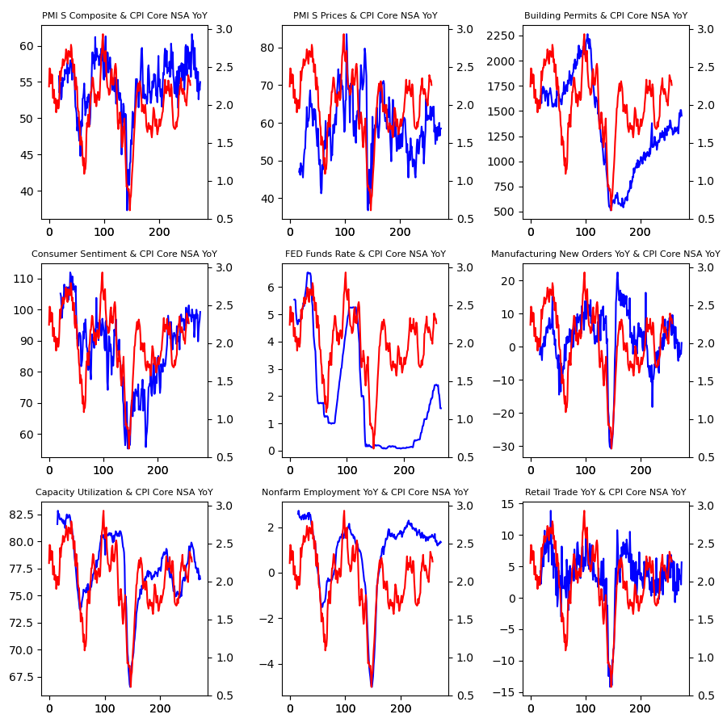

```python
# correlation visualization

import matplotlib.pyplot as plt
%matplotlib notebook

fig = plt.figure(figsize=(9,9))

x_values = data_final.columns[1:10]
y_value = data_final.columns[-1]

row = range(3)
column = range(3)
x_values_count = 0
subplot_index = 1

for r in row:
    for c in column:
        ax1 = fig.add_subplot(3,3,subplot_index)
        line1 = ax1.plot(data_final.index,data_final[x_values[x_values_count]], 'b-')
        ax1.yaxis.tick_left()
        plt.title(str(x_values[x_values_count])+' & '+str(y_value),fontdict={'fontsize':8})

        ax2 = fig.add_subplot(3,3,subplot_index, sharex=ax1, frameon=False)
        line2 = ax2.plot(data_final.index,data_final[y_value], 'r-')
        ax2.yaxis.tick_right()

        x_values_count += 1
        subplot_index += 1

plt.tight_layout()
```

```python
data_ml = data_final.dropna()

# dropping columns with high multi-colinearity --> tests performed bellow
data_ml = data_ml.drop(columns=['Capacity Utilization','PMI S Composite',
                                'Consumer Sentiment','Building Permits',
                               'Retail Trade YoY'])
data_ml
```

|  | Covering Date | PMI S Prices | FED Funds Rate | Manufacturing New Orders YoY | Nonfarm Employment YoY | CPI Core NSA YoY |
| --- | --- | --- | --- | --- | --- | --- |
| 21 | 04-2000 | 47.3 | 5.07 | -4.05 | 2.33 | 2.32 |
| 22 | 05-2000 | 48.5 | 5.22 | 0.53 | 2.49 | 2.43 |
| 23 | 06-2000 | 47.0 | 5.20 | 0.97 | 2.47 | 2.49 |
| 24 | 07-2000 | 45.5 | 5.42 | 0.07 | 2.53 | 2.49 |
| 25 | 08-2000 | 48.9 | 5.30 | 3.08 | 2.34 | 2.60 |
| ... | ... | ... | ... | ... | ... | ... |
| 253 | 08-2019 | 61.5 | 2.27 | 6.24 | 1.59 | 2.39 |
| 254 | 09-2019 | 61.8 | 2.40 | 8.39 | 1.60 | 2.36 |
| 255 | 10-2019 | 64.3 | 2.40 | 9.32 | 1.57 | 2.31 |
| 256 | 11-2019 | 60.7 | 2.41 | 3.50 | 1.67 | 2.32 |
| 257 | 12-2019 | 63.4 | 2.42 | 9.57 | 1.62 | 2.26 |

237 rows × 6 columns

```python
# multi-collinearity tests

from statsmodels.stats.outliers_influence import variance_inflation_factor
from statsmodels.tools.tools import add_constant
import warnings

def correlation_matrix():
    corr = data_ml[data_ml.columns[1:(len(data_ml.columns)-1)]].corr()
    corr = corr.style.background_gradient(cmap='coolwarm')
    return corr

def vif_with_constant():
    warnings.simplefilter(action='ignore', category=FutureWarning)
    vif_data = data_ml[data_ml.columns[1:(len(data_ml.columns)-1)]]
    X = add_constant(vif_data)
    vif = pd.DataFrame([variance_inflation_factor(X.values,i)
              for i in range(X.shape[1])],
              index=X.columns)
    vif.rename(columns={0:'VIF'},inplace=True)
    vif = vif.style.background_gradient(cmap='coolwarm')
    return vif

def vif_no_constant():
    X = data_ml[data_ml.columns[1:(len(data_ml.columns)-1)]]
    vif_data = pd.DataFrame()
    vif_data["X_variables"] = X.columns
    vif_data["VIF"] = [variance_inflation_factor(X.values, i)
                          for i in range(len(X.columns))]
    vif = vif_data.style.background_gradient(cmap='coolwarm')
    return vif
```

```python
correlation_matrix()
```

|  | PMI S Prices | FED Funds Rate | Manufacturing New Orders YoY | Nonfarm Employment YoY |
| --- | --- | --- | --- | --- |
| PMI S Prices | 1.000000 | 0.256856 | 0.668921 | 0.285569 |
| FED Funds Rate | 0.256856 | 1.000000 | 0.244088 | 0.390478 |
| Manufacturing New Orders YoY | 0.668921 | 0.244088 | 1.000000 | 0.543332 |
| Nonfarm Employment YoY | 0.285569 | 0.390478 | 0.543332 | 1.000000 |

```python
vif_with_constant()
```

|  | VIF |
| --- | --- |
| const | 93.487078 |
| PMI S Prices | 1.899962 |
| FED Funds Rate | 1.221472 |
| Manufacturing New Orders YoY | 2.412866 |
| Nonfarm Employment YoY | 1.627725 |

```python
vif_no_constant()
```

|  | X_variables | VIF |
| --- | --- | --- |
| 0 | PMI S Prices | 2.027507 |
| 1 | FED Funds Rate | 2.257043 |
| 2 | Manufacturing New Orders YoY | 1.536350 |
| 3 | Nonfarm Employment YoY | 1.979957 |

After multi-colinearity tests performed by correlation matrix and variance inflation factor, four independant variables were selected for regression analysis calculation.

Those variables are:

- Purchasing Managers Index with Prices subcomponent, released by Institute for Supply Management
- Federal Funds Effective Rate (Monthly data), released by Board of Governors of the Federal Reserve System (US)
- Manufacturers' New Orders: Total Manufacturing, released by U.S. Census Bureau (calculation: Year-Over-Year change)
- All Employees, Total Nonfarm, released by U.S. Bureau of Labor Statistics (calculation: Year-Over-Year change)

Following independant variables will be used for predicting Consumer Price Index for All Urban Consumers: All Items Less Food and Energy in U.S. City Average on Year-Over-Year change.

## Machine learning - Linear Regression

```python
#creating training and testing sets

from sklearn.model_selection import train_test_split

X = data_ml[['PMI S Prices',
             'FED Funds Rate',
             'Manufacturing New Orders YoY',
            'Nonfarm Employment YoY']]
y = data_ml['CPI Core NSA YoY']

X_train, X_test, y_train, y_test = train_test_split(X,y,random_state=0,test_size=0.2,train_size=0.8)

print('X_train shape: ',X_train.shape)
print('y_train shape: ',y_train.shape)
print('X_test shape: ', X_test.shape)
print('y_test shape: ', y_test.shape)
```

```
X_train shape:  (189, 4)
y_train shape:  (189,)
X_test shape:  (48, 4)
y_test shape:  (48,)
```

```python
# model selection

from sklearn.linear_model import LinearRegression
from sklearn.metrics import r2_score
import statsmodels.api as sm

def train_test_model():

    linreg = LinearRegression().fit(X_train,y_train)
    coef_ = linreg.coef_
    intercept_ = linreg.intercept_

    score_train = linreg.score(X_train, y_train)
    score_test = linreg.score(X_test, y_test)

    y_pred = linreg.predict(X_test)
    residuals = y_test - y_pred
    residuals_sq = residuals**2
    variance = sum(residuals_sq)/(len(residuals)-2)
    standard_error = variance ** 0.5

    print('Train coefficients are {} and train intercept is {:.5f}.'.format(coef_.round(5), intercept_))
    print('Linear Regression model train score is {:.2f} and test score is {:.2f}.'.format(score_train,score_test))
    print('Standard Deviation of train_test_model is {:.2f}%.'.format(standard_error))

def regression_statistics(X,y):

    N = len(X)
    p = len(X.columns) + 1
    X_with_intercept = np.empty(shape=(N, p), dtype=float)
    X_with_intercept[:, 0] = 1
    X_with_intercept[:, 1:p] = X.values

    ols = sm.OLS(y.values, X_with_intercept)
    ols_result = ols.fit()
    return ols_result.summary(title='Regression Statistics')

def classic_reg_model():

    linreg = LinearRegression().fit(X,y)
    coef_ = linreg.coef_
    intercept_ = linreg.intercept_

    score_train = linreg.score(X, y)

    y_pred = linreg.predict(X)
    residuals = y - y_pred
    residuals_sq = residuals**2
    variance = sum(residuals_sq)/(len(residuals)-2)
    standard_error = variance ** 0.5

    print('Train coefficients are {} and train intercept is {:.5f}.'.format(coef_.round(5), intercept_))
    print('Linear Regression model score is {:.2f}.'.format(score_train))
    print('Standard Deviation of classic_reg_model is {:.2f}%.'.format(standard_error))
```

```python
train_test_model()
```

```
Train coefficients are [-0.0005   0.09826  0.00723  0.13488] and train intercept is 1.73016.
Linear Regression model train score is 0.73 and test score is 0.77.
Standard Deviation of train_test_model is 0.22%.
```

```python
classic_reg_model()
```

```
Train coefficients are [-0.00151  0.09854  0.00862  0.13212] and train intercept is 1.77720.
Linear Regression model score is 0.74.
Standard Deviation of classic_reg_model is 0.23%.
```

```python
#regression statiustics of train_test_model

regression_statistics(X_test,y_test)
```

Regression Statistics

| Dep. Variable: | y | R-squared: | 0.796 |
| --- | --- | --- | --- |
| Model: | OLS | Adj. R-squared: | 0.777 |
| Method: | Least Squares | F-statistic: | 41.95 |
| Date: | Wed, 19 Jan 2022 | Prob (F-statistic): | 2.60e-14 |
| Time: | 01:18:24 | Log-Likelihood: | 9.2154 |
| No. Observations: | 48 | AIC: | -8.431 |
| Df Residuals: | 43 | BIC: | 0.9253 |
| Df Model: | 4 |  |  |
| Covariance Type: | nonrobust |  |  |

|  | coef | std err | t | P>\|t\| | [0.025 | 0.975] |
| --- | --- | --- | --- | --- | --- | --- |
| const | 1.9745 | 0.283 | 6.971 | 0.000 | 1.403 | 2.546 |
| x1 | -0.0059 | 0.005 | -1.202 | 0.236 | -0.016 | 0.004 |
| x2 | 0.1032 | 0.016 | 6.350 | 0.000 | 0.070 | 0.136 |
| x3 | 0.0163 | 0.006 | 2.947 | 0.005 | 0.005 | 0.027 |
| x4 | 0.1156 | 0.025 | 4.557 | 0.000 | 0.064 | 0.167 |

| Omnibus: | 4.892 | Durbin-Watson: | 1.978 |
| --- | --- | --- | --- |
| Prob(Omnibus): | 0.087 | Jarque-Bera (JB): | 3.711 |
| Skew: | -0.591 | Prob(JB): | 0.156 |
| Kurtosis: | 3.678 | Cond. No. | 567. |

Notes:  
[1] Standard Errors assume that the covariance matrix of the errors is correctly specified.

```python
#regression statistics of classic model

regression_statistics(X,y)
```

Regression Statistics

| Dep. Variable: | y | R-squared: | 0.736 |
| --- | --- | --- | --- |
| Model: | OLS | Adj. R-squared: | 0.731 |
| Method: | Least Squares | F-statistic: | 161.7 |
| Date: | Wed, 19 Jan 2022 | Prob (F-statistic): | 6.95e-66 |
| Time: | 01:18:26 | Log-Likelihood: | 12.184 |
| No. Observations: | 237 | AIC: | -14.37 |
| Df Residuals: | 232 | BIC: | 2.972 |
| Df Model: | 4 |  |  |
| Covariance Type: | nonrobust |  |  |

|  | coef | std err | t | P>\|t\| | [0.025 | 0.975] |
| --- | --- | --- | --- | --- | --- | --- |
| const | 1.7772 | 0.146 | 12.181 | 0.000 | 1.490 | 2.065 |
| x1 | -0.0015 | 0.003 | -0.596 | 0.552 | -0.007 | 0.003 |
| x2 | 0.0985 | 0.008 | 11.741 | 0.000 | 0.082 | 0.115 |
| x3 | 0.0086 | 0.002 | 3.450 | 0.001 | 0.004 | 0.014 |
| x4 | 0.1321 | 0.012 | 11.216 | 0.000 | 0.109 | 0.155 |

| Omnibus: | 2.604 | Durbin-Watson: | 0.220 |
| --- | --- | --- | --- |
| Prob(Omnibus): | 0.272 | Jarque-Bera (JB): | 2.002 |
| Skew: | 0.055 | Prob(JB): | 0.367 |
| Kurtosis: | 2.563 | Cond. No. | 578. |

Notes:  
[1] Standard Errors assume that the covariance matrix of the errors is correctly specified.

```python
# plotting regression model coefficients

def regression_model_subplots():

    linreg = LinearRegression().fit(X_train,y_train)
    coef_ = linreg.coef_
    intercept_ = linreg.intercept_

    fig = plt.figure(figsize=(9,5))

    row = range(2)
    column = range(2)
    X_count = 0
    subplot_index = 1

    for r in row:
        for c in column:
            ax = fig.add_subplot(2,2,subplot_index)
            line = ax.plot(X[X.columns[X_count]], coef_[X_count] * X[X.columns[X_count]] + intercept_, 'k.')
            scatter = plt.scatter(X[X.columns[X_count]], y, marker= 'o', s=10, alpha=0.8)
            title = plt.title(str(X.columns[X_count])+' & '+'CPI Core YoY',fontdict={'fontsize':8})

            X_count += 1
            subplot_index += 1

    plt.tight_layout()
```

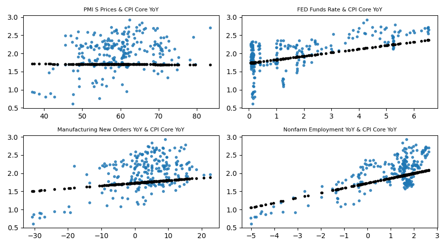

```python
regression_model_subplots()
```

```python
# plotting forecasted and real data

from matplotlib.ticker import FixedLocator

def forecast_plot():

    model = LinearRegression().fit(X,y)
    coef_ = model.coef_
    intercept_ = model.intercept_

    df_forecast = pd.concat([X,y],axis=1)
    df_forecast.rename(columns={'PMI S Prices':'X1','FED Funds Rate':'X2','Manufacturing New Orders YoY':'X3',
                               'Nonfarm Employment YoY':'X4','CPI Core NSA YoY':'y'},inplace=True)
    df_forecast['y_pred'] = (coef_[0]*df_forecast['X1'])+(coef_[1]*df_forecast['X2'])+\
                            (coef_[2]*df_forecast['X3'])+(coef_[3]*df_forecast['X4'])+intercept_
    df_forecast['Date'] = data_ml['Covering Date']

    fig = plt.figure(figsize=(9,6))
    y_real = plt.plot(df_forecast['Date'],df_forecast['y'],c='black',label='CPI YoY Real')
    y_pred = plt.plot(df_forecast['Date'],df_forecast['y_pred'],c='red',label='CPI YoY Forecasted')
    x_axis = plt.xticks(list(range(5,260,12)))
    y_axis = plt.yticks([0.50,0.75,1.00,1.25,1.50,1.75,2.00,2.25,2.50,2.75,3.00])
    x_ax = plt.gca().xaxis
    for item in x_ax.get_ticklabels():
        item.set_rotation(30)
    x_name = plt.xlabel('Date')
    y_name = plt.ylabel('CPI YoY (%)')
    title = plt.title('CPI YoY - Real and Forecasted')
    legend = plt.legend()
    grid = plt.grid(alpha=0.4)

    tight = plt.tight_layout()
    return y_real
```

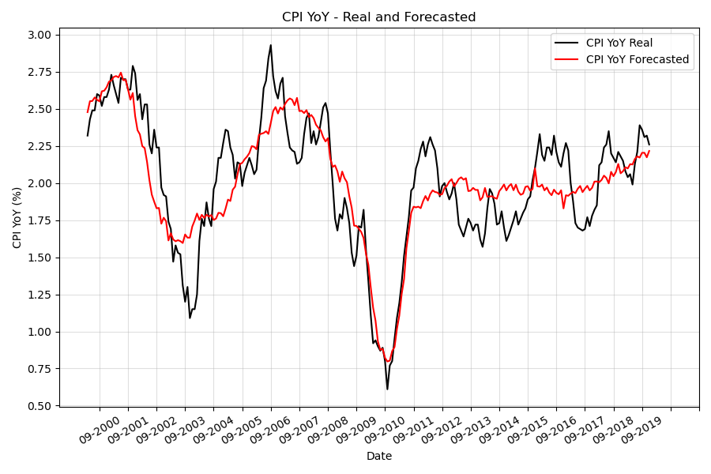

```python
forecast_plot()
```